# SIR assumptions

- Individuals belong to one of three groups, susceptible, infected or recovered
- The normal SIR model assumes that recovered people cannot return to the infected category, this is not the case with drug use, where relapse is prevalent
- Change is limited to day by day
- the rate of movement between groups is linear such that:
  $$\frac{ds}{dt} = -a s i$$
  $$\frac{di}{dt} = a s i + b r i - c i$$
  $$\frac{dr}{dt} = -b r i + c i$$
  It can be seen then:
  $$\frac{ds}{dt} + \frac{di}{dt} + \frac{dr}{dt} = 0$$

## Parameters:

a - rate people move from susceptible to infected, based on interactions between susceptible and infected

b - rate people move from recovered to infected as portion of total people, based on interactions with infected people

c - rate people move from infected to recovered as portion of total people

This model is iterative, meaning $x_{n+1} = A x_n$, which can then be expanded over time.

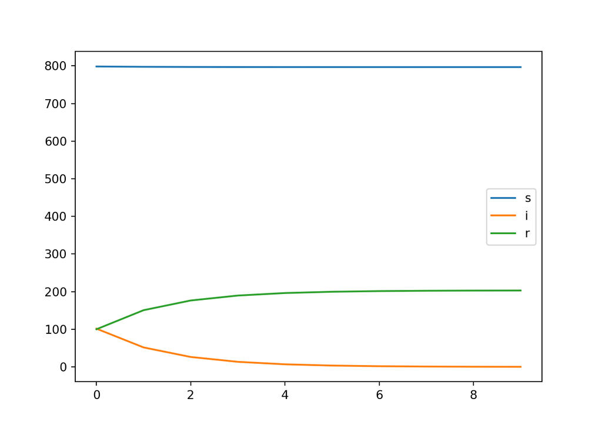

```python
import numpy as np
import pandas
import matplotlib.pyplot as plt
pop_init = 1000
pop_add = 200
a = 0.01
b = 0.01
c = 0.5

steps = 10

vect_initial = np.array([pop_init - pop_add,pop_add,0]).T # vector of day index, suseptable, infected and recovered people

output = pandas.DataFrame(columns = ['day', 's', 'i', 'r'])
j = 0
vect = vect_initial.copy()

while j < steps:
    vectplus1 = np.zeros([3])
    s = vect[0]
    i = vect[1]
    r = vect[2]
    vectplus1[0] = s - a *s*i/pop_init
    vectplus1[1] = i + a *s*i/pop_init + b*r*i/pop_init - c*i
    vectplus1[2] = r - b*r*i/pop_init + c*i
    output.loc[j] = np.concatenate((np.array([j]),vectplus1.T))
    vect = vectplus1.copy()
    j+=1

plt.plot(output['day'],output['s'])
plt.plot(output['day'],output['i'])
plt.plot(output['day'],output['r'])
plt.legend(['s','i','r'])
plt.show()
```

## Functions

$$\frac{ds}{dt} = -a s i - d s$$
$$\frac{di}{dt} = a s i + b r i - c i + d s + e r$$
$$\frac{dr}{dt} = -b r i + c i - e r$$
It can be seen then:
$$\frac{ds}{dt} + \frac{di}{dt} + \frac{dr}{dt} = 0$$

## Parameters:

a - rate people move from susceptible to infected, based on interactions between susceptible and infected

b - rate people move from recovered to infected as portion of total people, based on interactions with infected people

c - rate people move from infected to recovered as portion of total people

d - portion of suseptible people who become addicted based on spontanious use

e - portion of recovered people who become addicted based on spontanious use

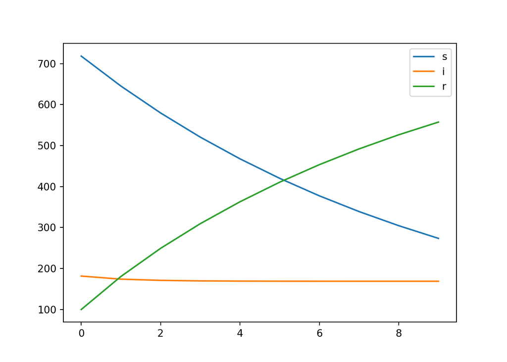

```python
import numpy as np
import pandas
import matplotlib.pyplot as plt
pop_init = 1000
pop_add = 200
a = 0.01
b = 0.01
c = 0.5
d = 0.1
e = 0.1

steps = 10

vect_initial = np.array([pop_init - pop_add,pop_add,0]).T # vector of day index, suseptable, infected and recovered people

output = pandas.DataFrame(columns = ['day', 's', 'i', 'r'])
j = 0
vect = vect_initial.copy()

while j < steps:
    vectplus1 = np.zeros([3])
    s = vect[0]
    i = vect[1]
    r = vect[2]
    vectplus1[0] = s - a *s*i/pop_init - d*s
    vectplus1[1] = i + a *s*i/pop_init + b*r*i/pop_init - c*i + d*s + e*r
    vectplus1[2] = r - b*r*i/pop_init + c*i -e*r
    output.loc[j] = np.concatenate((np.array([j]),vectplus1.T))
    vect = vectplus1.copy()
    j+=1

plt.plot(output['day'],output['s'])
plt.plot(output['day'],output['i'])
plt.plot(output['day'],output['r'])
plt.legend(['s','i','r'])
plt.show()
```

Looking at the above model, we can see that it doesn’t reflect drug use in communities. One obvious one is that many people become addicted and move into the recovering population throughout the course of the simulation. This is because, unlike disease, people can use the drug without being addicted. This means we can add a new group w to symbolise people trying the drug. People in this group will then move back to the susceptible group or become addicted. People who are recovering from addiction will not go back into this trying stage and will simply become addicted if they relaspe. This is inline with the ‘lifelong’ model of addiction, where relaspe is triggered as soon as the person begins taking the drug again.

## Functions

$$\frac{ds}{dt} = -a s (i + w) - d s + f w$$
$$\frac{dw}{dt} = a s (i + w) + d s - f w - g w$$
$$\frac{di}{dt} = g w + b r (i + w) - c i + er$$
$$\frac{dr}{dt} = -b r (i + w) + c i - e r$$
It can be seen then:
$$\frac{ds}{dt} + \frac{dw}{dt}+ \frac{di}{dt} + \frac{dr}{dt} = 0$$

## Parameters:

b - rate people move from recovered to infected as portion of total people, based on interactions with infected/trying

c - rate people move from infected to recovered as portion of total people

e - portion of recovered people who become addicted based on spontaneous use

g - movement from trying to addicted

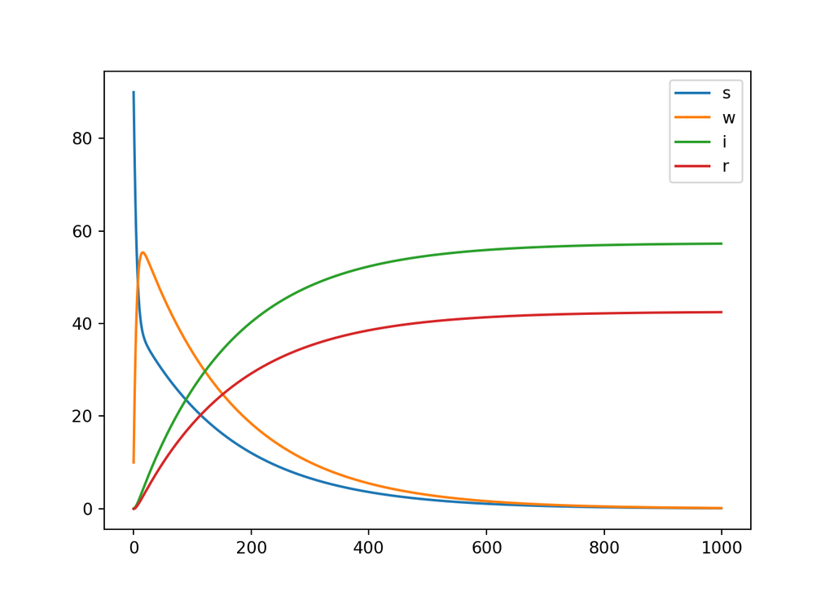

```python
import numpy as np
import pandas
import matplotlib.pyplot as plt
pop_init = 100
a = 0.001
b = 0.01
c = 0.5
d = 0.1
e = 0.1
f = 0.1
g = 0.01

steps = 1000

vect_initial = np.array([pop_init,0,0,0]).T # vector of day index, suseptable, infected and recovered people

output = pandas.DataFrame(columns = ['day', 's', 'w',  'i', 'r'])
j = 0
vect = vect_initial.copy()

while j < steps:
    vectplus1 = np.zeros([4])
    s = vect[0]
    w = vect[1]
    i = vect[2]
    r = vect[3]
    vectplus1[0] = s - a*s*(i+w) - d * s + f*w
    vectplus1[1] = w + a*s*(i+w) + d * s - f*w - g*w
    vectplus1[2] = i + g*w + b*r*(i+w) - c*i + e*r
    vectplus1[3] = r - b*r*(i+w) + c*i - e*r
    output.loc[j] = np.concatenate((np.array([j]),vectplus1.T))
    vect = vectplus1.copy()
    j+=1

plt.plot(output['day'],output['s'])
plt.plot(output['day'],output['w'])
plt.plot(output['day'],output['i'])
plt.plot(output['day'],output['r'])
plt.legend(['s','w','i','r'])
plt.show()
```